# Lab1: Initial Setup

Ukrainian Biological Data Science Summer School 2024

08-13/07/2024

# R and RStudio

This lab will help you prepare your computer environment for the practical component of UBDS^3. You will learn how to install or update R and RStudio, as well as how to obtain R-packages, and makes sure you have right versions of the software.

## Getting R

- **R is a free software** available for download from [CRAN](https://cran.rstudio.com/), the Comprehensive R Archive Network.  
  The latest release of R is 4.4.1, *Race for Your Life* (released on 2024/06/14).
- To install or update R **go to https://cran.rstudio.com/ and download** the precompiled binary distribution for your operating system. The links for Linux/Mac/Windows appear on the top of the website, as shown in the image below.  
  After downloading the appropriate file, open it and **follow the instructions to complete the installation.**

[figure not shown]

## Getting RStudio

- **RStudio is an IDE** (Integrated Development Environment) for R. It provides you with a powerful interface for working with R, which includes a **text editor** where you can write your code and/or notes.
- **To get RStudio** go to https://posit.co/download/rstudio-desktop/#download and download a free version by clicking the blue button ‘DOWNLOAD RSTUDIO DESKTOP’. Open the file and follow the instructions.

[figure not shown]

  If you don’t see the appropriate version for your OS, you can scroll down to find it

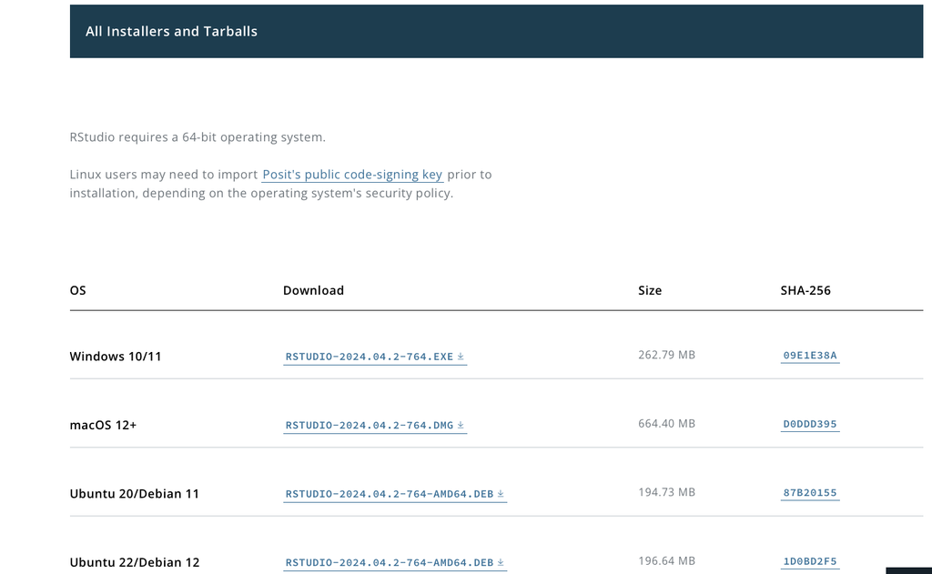

**If you encounter issues don’t hesitate to ask the TAs for assistance.**

## Getting started

There are two ways you can use R:

- access through a **command-line interpreter**:  
  open the terminal and type R.

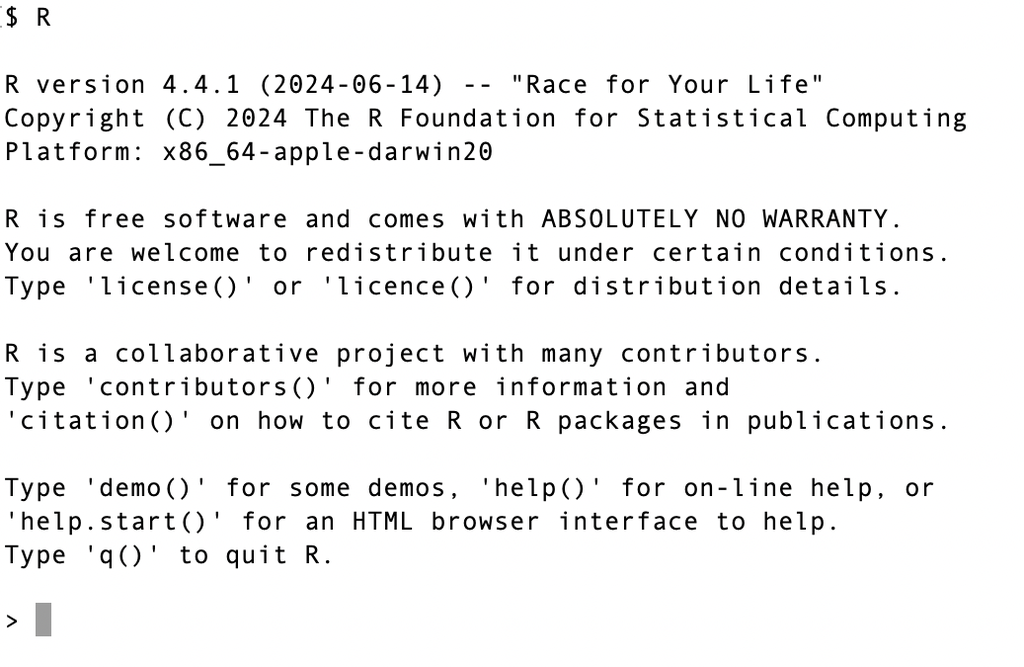

- **Rstudio interface**:  
  open Rstudio, the interface can have 4 panels:
  - top-left: scripts and files
  - bottom-left: R console
  - top-right: objects, history and environment
  - bottom-right: tree of folders(files), graph window(plots), packages, help window, viewer

[figure not shown]

To test whether the installation of R and RStudio was successful, type in a simple arithmetic calculation in the Console panel (bottom left) e.g.:

```r
1+1
2^3
```

to see if the commands execute and the results are correct.

# R document types

RStudio incorporates a very user-friendly text editor. You can edit different type of files:

- plain text with notes and comments
- write, debug and execute your R code
- write and run notebooks using `rmarkdown`, `knitr` and `quarto` - see lab on quarto

## R Scripts

An R-script is a simple text file storing all the R code you want to execute.  
As a good practice, when coding, gather all your code in a text file, **!!with comments!!**.  
About comments:

- in a line, everything that is after the ‘#’ is a comment (and is ignored by the program)
- they are essential for others (and for you later!) to know what the program is doing at every step

#### create

To start a new R-script, press a black triangle dropdown button in the top-left corner of your RStudio window. You will see multiple options of file formats to choose from, like in the picture below:

[figure not shown]

Choose the first option `R Script`.  
You will see a new, source code panel, with a tab `Untitled1` appear on top of your R console. Here, you can write and edit your R code.

Now, type in a few lines of simple code into `Untitled1`, e.g.

```r
x <- seq(0, 10, length.out = 1000)
y <- x*sin(2*pi*x)
plot(x, y)
```

#### execute from Rstudio

To execute your code select/highlight the portion you want to evaluate and then you have two options:

1. or press the `Run` button on the top-right corner of the panel (green circle in the image below)
2. or press a keyboard shortcut: `Ctrl` (`Command` on macOS X) + `Enter`

#### save

To save your code, press the floppy disk button (blue circle in the image below). Pick a location and a name for your file, and press `Save`. Your R-script file will have an extention ‘.R’ to indicate it contains R code.

[figure not shown]

#### run from command line and `source`

- You can run the script from command line of your terminal using the following: `Rscript my_rscript.R`
- You can also use the function `source("my_rscript.R")` to execute an entire R-script file from the R console or another R script.